## Data Report Markdown

Group 5

- Ong Heng Kiat (17205923/1)
- Gan Joo Han (17206504/1)
- Mohammad Afif Bin Mohammad Fauzi (17197449/2)
- Nurul Asyiqin binti Mohd Harmizi (17065343/2)
- Muhammad Iqmal Hafiy Bin Hamdi (17077341/2)

### Introduction

Rapidly rising unemployment and an extremely low demand for labour are fundamental labour market problems currently facing all countries. Previous research has shown that the unemployment experience increases the risk of suffering from negative psychological outcomes, although, the effect appears to differ depending on life situation and individual characteristics. This heterogeneous effect of unemployment on mental health raises the question whether the labour market context, in the form of the local unemployment rate or vacancy rate, could mediate the effect in a similar manner. Such an effect of labour market conditions on the effect of unemployment on mental health, where the context affects the health effect, could be called, using Greenland and Morgenstern’s term, ecological effect modification.

### Problem Statement

What are the factors that will affect the employment rate? How much do these factors affect it? Why these factors can affect the employment rate so much?

### Data Acquisition

For this assignment, we will be implementing all the knowledge that we have learned to produce valuable insights using R, from data acquisition to building a simple web app using Shiny.

The data set we choose to be used for our question is a data set that is obtained through a paid research survey to explore the linkage between the mental illness and unemployment rate.

```r
library("openxlsx")
#Set working directory
setwd("C:/Users/user/Documents/R/Employment_Rate_Analysis_WebApp")
```

However, there is a fly in the ointment which the data set is not a cleaned data set. It has duplicate observations, syntax error, not standardized format, missing records and so on which require some time to clean it. The data set is in the format of xlsx excel file.

### Data Extraction and Cleaning

We will extract several useful features like **salary**, **age**, **position**, **education level** and so on from the data set acquired into a form that is easier for further processing and analysis.

```r
#Read the data sets into Rstudio
data <- read.xlsx("data/raw_dataset.xlsx")

#Analysis the data
View(data)
class(data) #check type of class
```

```
## [1] "data.frame"
```

```r
dim(data) #check row & column
```

```
## [1] 355  29
```

```r
str(data) #Check the structure of the data sets
```

```
## 'data.frame':    355 obs. of  29 variables:
##  $ X1                                              : chr  "1" "2" "3" "4" ...
##  $ Employed                                        : num  1 0 1 1 0 1 1 1 1 1 ...
##  $ Mental.Illness                                  : num  0 0 1 0 0 1 0 0 1 0 ...
##  $ Education                                       : chr  "Undergraduate" "Highschool" "Phd" "Undergraduate" ...
##  $ Have.Computer                                   : chr  "1" "0" "1" "1" ...
##  $ Days.Hopitalized.for.Mental.illeness            : num  0 0 0 0 0 35 0 0 0 0 ...
##  $ Legally.Disabled                                : chr  "0" "0" "0" "0" ...
##  $ Internet.Access                                 : chr  "1" "1" "1" "1" ...
##  $ Live.With.Parents                               : chr  "0" "0" "0" "0" ...
##  $ Gap.In.Resume..Months.                          : num  36 24 1 0 11 33 0 0 0 0 ...
##  $ Total.Annual.Income..USD.                       : num  42 35 22 100 0 32 0 1 11 73 ...
##  $ Study                                           : num  0 1 1 1 1 1 1 1 1 1 ...
##  $ Annual.income.from.social.welfare.programs..USD.: num  0 0 0 0 0 30 0 0 0 0 ...
##  $ Received.Food.Stamps                            : num  0 0 0 0 0 0 0 0 0 0 ...
##  $ Section.8.Housing                               : num  0 0 0 0 0 0 0 0 0 0 ...
##  $ Frequency.Hospitalized                          : num  0 0 0 0 0 4 0 0 0 0 ...
##  $ Lack.of.concentration                           : num  0 1 1 0 0 1 0 0 1 1 ...
##  $ Anxiety                                         : chr  "0" "1" "1" "0" ...
##  $ Depression                                      : num  0 1 1 0 0 1 0 0 1 1 ...
##  $ Obsessive.thinking                              : num  0 1 0 0 0 1 0 0 0 0 ...
##  $ Mood.swings                                     : num  0 0 0 0 0 1 0 0 0 0 ...
##  $ Panic.attacks                                   : num  0 1 1 0 0 1 0 0 1 0 ...
##  $ Compulsive.behavior                             : num  0 0 0 0 0 1 0 0 1 0 ...
##  $ Tiredness                                       : chr  "0" "0" "1" "0" ...
##  $ Age                                             : chr  "18-29" "30-44" "18-29" "30-44" ...
##  $ Gender                                          : chr  "Female" "Male" "Male" "Male" ...
##  $ Household.Income                                : chr  "$25,000-$49,999" "$25,000-$49,999" "$50,000-$74,999" "$150,000-$174,999" ...
##  $ Region                                          : chr  "Pacific" "Mountain" "East South Central" "Pacific" ...
##  $ Device.Type                                     : chr  "iOS Phone / Tablet" "Android Phone / Tablet" "MacOS Desktop / Laptop" "MacOS Desktop / Laptop" ...
```

```r
summary(data)
```

```
##       X1               Employed      Mental.Illness    Education
##  Length:355         Min.   :0.0000   Min.   :0.0000   Length:355
##  Class :character   1st Qu.:0.0000   1st Qu.:0.0000   Class :character
##  Mode  :character   Median :1.0000   Median :0.0000   Mode  :character
##                     Mean   :0.6845   Mean   :0.2394
##                     3rd Qu.:1.0000   3rd Qu.:0.0000
##                     Max.   :1.0000   Max.   :1.0000
##  Have.Computer      Days.Hopitalized.for.Mental.illeness Legally.Disabled
##  Length:355         Min.   :  0.000                      Length:355
##  Class :character   1st Qu.:  0.000                      Class :character
##  Mode  :character   Median :  0.000                      Mode  :character
##                     Mean   :  2.769
##                     3rd Qu.:  0.000
##                     Max.   :100.000
##  Internet.Access    Live.With.Parents  Gap.In.Resume..Months.
##  Length:355         Length:355         Min.   :  0.000
##  Class :character   Class :character   1st Qu.:  0.000
##  Mode  :character   Mode  :character   Median :  0.000
##                                        Mean   :  8.349
##                                        3rd Qu.:  3.500
##                                        Max.   :100.000
##  Total.Annual.Income..USD.     Study
##  Min.   :  0.00            Min.   :0.0000
##  1st Qu.: 14.00            1st Qu.:1.0000
##  Median : 31.00            Median :1.0000
##  Mean   : 38.23            Mean   :0.8873
##  3rd Qu.: 55.00            3rd Qu.:1.0000
##  Max.   :100.00            Max.   :1.0000
##  Annual.income.from.social.welfare.programs..USD. Received.Food.Stamps
##  Min.   :  0.00                                   Min.   :0.00000
##  1st Qu.:  0.00                                   1st Qu.:0.00000
##  Median :  0.00                                   Median :0.00000
##  Mean   :  3.38                                   Mean   :0.06479
##  3rd Qu.:  0.00                                   3rd Qu.:0.00000
##  Max.   :100.00                                   Max.   :1.00000
##  Section.8.Housing Frequency.Hospitalized Lack.of.concentration
##  Min.   :0.00000   Min.   :  0.000        Min.   :0.0000
##  1st Qu.:0.00000   1st Qu.:  0.000        1st Qu.:0.0000
##  Median :0.00000   Median :  0.000        Median :0.0000
##  Mean   :0.01972   Mean   :  1.141        Mean   :0.1521
```

[output cut: 8 more lines]

```
##                     Max.   :1.0000   Max.   :1.0000     Max.   :1.0000
##  Panic.attacks    Compulsive.behavior  Tiredness             Age
##  Min.   :0.0000   Min.   :0.00000     Length:355         Length:355
##  1st Qu.:0.0000   1st Qu.:0.00000     Class :character   Class :character
##  Median :0.0000   Median :0.00000     Mode  :character   Mode  :character
##  Mean   :0.1493   Mean   :0.08451
##  3rd Qu.:0.0000   3rd Qu.:0.00000
##  Max.   :1.0000   Max.   :1.00000
##     Gender          Household.Income      Region          Device.Type
##  Length:355         Length:355         Length:355         Length:355
##  Class :character   Class :character   Class :character   Class :character
##  Mode  :character   Mode  :character   Mode  :character   Mode  :character
##
##
##
```

Then, we transform the data into a more beautiful data in such a way that it would be easier to be managed and also analyzed. This process includes detecting and correcting or removing the unwanted records such as duplicate records and inaccurate records.

```r
###Cleaning process
#Convert Data Type
data$NA.<- NULL  #remove entire column 1
data$Employed <- as.logical(as.integer(as.character(data$Employed)))
data$Mental.Illness <- as.logical(as.integer(as.character(data$Mental.Illness)))
data$Education <- as.character(data$Education)
data$Have.Computer <- as.logical(as.integer(as.character(data$Have.Computer)))
data$Legally.Disabled <- as.logical(as.integer(as.character(data$Legally.Disabled)))
data$Internet.Access <- as.logical(as.integer(as.character(data$Internet.Access)))
data$Live.With.Parents <- as.logical(as.integer(as.character(data$Live.With.Parents)))
data$Study <- as.logical(as.integer(as.character(data$Study)))
data$Received.Food.Stamps <- as.logical(data$Received.Food.Stamps)
data$Section.8.Housing <- as.logical(data$Section.8.Housing)
data$Lack.of.concentration <- as.logical(data$Lack.of.concentration)
data$Anxiety <- as.logical(as.integer(as.character(data$Anxiety)))
data$Depression <- as.logical(data$Depression)
data$Obsessive.thinking <- as.logical(data$Obsessive.thinking)
data$Mood.swings <- as.logical(data$Mood.swings)
data$Panic.attacks <- as.logical(data$Panic.attacks)
data$Compulsive.behavior <- as.logical(data$Compulsive.behavior)
data$Tiredness <- as.logical(as.integer(as.character(data$Tiredness)))

#convert data type
data$Age <- as.character(data$Age)
data$Gender <- as.character(data$Gender)
data$Household.Income <- as.character(data$Household.Income)
data$Region <- as.character(data$Region)
data$Device.Type <- as.character(data$Device.Type)

# Remove duplicate data rows
data <- unique(data)

#Make all lowercase in variable Education
data$Education <- tolower(data$Education)
```

```r
###Replacing Na / Null value

#Check number of null data before removing
sum(is.na(data))
```

```
## [1] 10
```

```r
#Method 1
#Replace all null value with Mode by referring to summary()
summary(data)
```

```
##       X1             Employed       Mental.Illness   Education
##  Length:354         Mode :logical   Mode :logical   Length:354
##  Class :character   FALSE:112       FALSE:270       Class :character
##  Mode  :character   TRUE :242       TRUE :84        Mode  :character
##
##
##
##  Have.Computer   Days.Hopitalized.for.Mental.illeness Legally.Disabled
##  Mode :logical   Min.   :  0.000                      Mode :logical
##  FALSE:44        1st Qu.:  0.000                      FALSE:315
##  TRUE :309       Median :  0.000                      TRUE :36
##  NA's :1         Mean   :  2.777                      NA's :3
##                  3rd Qu.:  0.000
##                  Max.   :100.000
##  Internet.Access Live.With.Parents Gap.In.Resume..Months.
##  Mode :logical   Mode :logical     Min.   :  0.000
##  FALSE:12        FALSE:314         1st Qu.:  0.000
##  TRUE :341       TRUE :38          Median :  0.000
##  NA's :1         NA's :2           Mean   :  8.373
##                                    3rd Qu.:  3.750
##                                    Max.   :100.000
##  Total.Annual.Income..USD.   Study
##  Min.   :  0.00            Mode :logical
##  1st Qu.: 14.00            FALSE:40
##  Median : 31.50            TRUE :314
##  Mean   : 38.27
##  3rd Qu.: 55.00
##  Max.   :100.00
##  Annual.income.from.social.welfare.programs..USD. Received.Food.Stamps
##  Min.   :  0.00                                   Mode :logical
##  1st Qu.:  0.00                                   FALSE:331
##  Median :  0.00                                   TRUE :23
##  Mean   :  3.39
##  3rd Qu.:  0.00
##  Max.   :100.00
##  Section.8.Housing Frequency.Hospitalized Lack.of.concentration  Anxiety
##  Mode :logical     Min.   :  0.000        Mode :logical         Mode :logical
##  FALSE:347         1st Qu.:  0.000        FALSE:300             FALSE:249
##  TRUE :7           Median :  0.000        TRUE :54              TRUE :104
##                    Mean   :  1.144                              NA's :1
```

[output cut: 8 more lines]

```
##
##  Compulsive.behavior Tiredness           Age               Gender
##  Mode :logical       Mode :logical   Length:354         Length:354
##  FALSE:324           FALSE:248       Class :character   Class :character
##  TRUE :30            TRUE :105       Mode  :character   Mode  :character
##                      NA's :1
##
##
##  Household.Income      Region          Device.Type
##  Length:354         Length:354         Length:354
##  Class :character   Class :character   Class :character
##  Mode  :character   Mode  :character   Mode  :character
##
##
##
```

```r
data$Have.Computer[is.na(data$Have.Computer)] <- TRUE
data$Legally.Disabled[is.na(data$Legally.Disabled)] <- FALSE
data$Internet.Access[is.na(data$Internet.Access)] <- TRUE
data$Live.With.Parents[is.na(data$Live.With.Parents)] <- FALSE
data$Anxiety[is.na(data$Anxiety)]<-FALSE
data$Tiredness[is.na(data$Tiredness)] <- FALSE

#Method 2
#Simply delete column with null value
#data <- na.omit(data)

#Check number of null data after removing
sum(is.na(data))
```

```
## [1] 1
```

```r
#Analysis the data
str(data)
```

```
## 'data.frame':    354 obs. of  29 variables:
##  $ X1                                              : chr  "1" "2" "3" "4" ...
##  $ Employed                                        : logi  TRUE FALSE TRUE TRUE FALSE TRUE ...
##  $ Mental.Illness                                  : logi  FALSE FALSE TRUE FALSE FALSE TRUE ...
##  $ Education                                       : chr  "undergraduate" "highschool" "phd" "undergraduate" ...
##  $ Have.Computer                                   : logi  TRUE FALSE TRUE TRUE TRUE TRUE ...
##  $ Days.Hopitalized.for.Mental.illeness            : num  0 0 0 0 0 35 0 0 0 0 ...
##  $ Legally.Disabled                                : logi  FALSE FALSE FALSE FALSE FALSE TRUE ...
##  $ Internet.Access                                 : logi  TRUE TRUE TRUE TRUE TRUE TRUE ...
##  $ Live.With.Parents                               : logi  FALSE FALSE FALSE FALSE TRUE FALSE ...
##  $ Gap.In.Resume..Months.                          : num  36 24 1 0 11 33 0 0 0 0 ...
##  $ Total.Annual.Income..USD.                       : num  42 35 22 100 0 32 0 1 11 73 ...
##  $ Study                                           : logi  FALSE TRUE TRUE TRUE TRUE TRUE ...
##  $ Annual.income.from.social.welfare.programs..USD.: num  0 0 0 0 0 30 0 0 0 0 ...
##  $ Received.Food.Stamps                            : logi  FALSE FALSE FALSE FALSE FALSE FALSE ...
##  $ Section.8.Housing                               : logi  FALSE FALSE FALSE FALSE FALSE FALSE ...
##  $ Frequency.Hospitalized                          : num  0 0 0 0 0 4 0 0 0 0 ...
##  $ Lack.of.concentration                           : logi  FALSE TRUE TRUE FALSE FALSE TRUE ...
##  $ Anxiety                                         : logi  FALSE TRUE TRUE FALSE FALSE TRUE ...
##  $ Depression                                      : logi  FALSE TRUE TRUE FALSE FALSE TRUE ...
##  $ Obsessive.thinking                              : logi  FALSE TRUE FALSE FALSE FALSE TRUE ...
##  $ Mood.swings                                     : logi  FALSE FALSE FALSE FALSE FALSE TRUE ...
##  $ Panic.attacks                                   : logi  FALSE TRUE TRUE FALSE FALSE TRUE ...
##  $ Compulsive.behavior                             : logi  FALSE FALSE FALSE FALSE FALSE TRUE ...
##  $ Tiredness                                       : logi  FALSE FALSE TRUE FALSE FALSE TRUE ...
##  $ Age                                             : chr  "18-29" "30-44" "18-29" "30-44" ...
##  $ Gender                                          : chr  "Female" "Male" "Male" "Male" ...
##  $ Household.Income                                : chr  "$25,000-$49,999" "$25,000-$49,999" "$50,000-$74,999" "$150,000-$174,999" ...
##  $ Region                                          : chr  "Pacific" "Mountain" "East South Central" "Pacific" ...
##  $ Device.Type                                     : chr  "iOS Phone / Tablet" "Android Phone / Tablet" "MacOS Desktop / Laptop" "MacOS Desktop / Laptop" ...
```

```r
dim(data)
```

```
## [1] 354  29
```

```r
summary(data)
```

```
##       X1             Employed       Mental.Illness   Education
##  Length:354         Mode :logical   Mode :logical   Length:354
##  Class :character   FALSE:112       FALSE:270       Class :character
##  Mode  :character   TRUE :242       TRUE :84        Mode  :character
##
##
##
##  Have.Computer   Days.Hopitalized.for.Mental.illeness Legally.Disabled
##  Mode :logical   Min.   :  0.000                      Mode :logical
##  FALSE:44        1st Qu.:  0.000                      FALSE:318
##  TRUE :310       Median :  0.000                      TRUE :36
##                  Mean   :  2.777
##                  3rd Qu.:  0.000
##                  Max.   :100.000
##  Internet.Access Live.With.Parents Gap.In.Resume..Months.
##  Mode :logical   Mode :logical     Min.   :  0.000
##  FALSE:12        FALSE:316         1st Qu.:  0.000
##  TRUE :342       TRUE :38          Median :  0.000
##                                    Mean   :  8.373
##                                    3rd Qu.:  3.750
##                                    Max.   :100.000
##  Total.Annual.Income..USD.   Study
##  Min.   :  0.00            Mode :logical
##  1st Qu.: 14.00            FALSE:40
##  Median : 31.50            TRUE :314
##  Mean   : 38.27
##  3rd Qu.: 55.00
##  Max.   :100.00
##  Annual.income.from.social.welfare.programs..USD. Received.Food.Stamps
##  Min.   :  0.00                                   Mode :logical
##  1st Qu.:  0.00                                   FALSE:331
##  Median :  0.00                                   TRUE :23
##  Mean   :  3.39
##  3rd Qu.:  0.00
##  Max.   :100.00
##  Section.8.Housing Frequency.Hospitalized Lack.of.concentration  Anxiety
##  Mode :logical     Min.   :  0.000        Mode :logical         Mode :logical
##  FALSE:347         1st Qu.:  0.000        FALSE:300             FALSE:250
##  TRUE :7           Median :  0.000        TRUE :54              TRUE :104
##                    Mean   :  1.144
```

[output cut: 8 more lines]

```
##
##  Compulsive.behavior Tiredness           Age               Gender
##  Mode :logical       Mode :logical   Length:354         Length:354
##  FALSE:324           FALSE:249       Class :character   Class :character
##  TRUE :30            TRUE :105       Mode  :character   Mode  :character
##
##
##
##  Household.Income      Region          Device.Type
##  Length:354         Length:354         Length:354
##  Class :character   Class :character   Class :character
##  Mode  :character   Mode  :character   Mode  :character
##
##
##
```

```r
#List the name of column
colnames(data)
```

```
##  [1] "X1"
##  [2] "Employed"
##  [3] "Mental.Illness"
##  [4] "Education"
##  [5] "Have.Computer"
##  [6] "Days.Hopitalized.for.Mental.illeness"
##  [7] "Legally.Disabled"
##  [8] "Internet.Access"
##  [9] "Live.With.Parents"
## [10] "Gap.In.Resume..Months."
## [11] "Total.Annual.Income..USD."
## [12] "Study"
## [13] "Annual.income.from.social.welfare.programs..USD."
## [14] "Received.Food.Stamps"
## [15] "Section.8.Housing"
## [16] "Frequency.Hospitalized"
## [17] "Lack.of.concentration"
## [18] "Anxiety"
## [19] "Depression"
## [20] "Obsessive.thinking"
## [21] "Mood.swings"
## [22] "Panic.attacks"
## [23] "Compulsive.behavior"
## [24] "Tiredness"
## [25] "Age"
## [26] "Gender"
## [27] "Household.Income"
## [28] "Region"
## [29] "Device.Type"
```

Finally, we renamed the columns so that it is readable for users to understand.

```r
#Renaming column

names(data)[names(data) == "Mental.Illness" ] <- "Mental Illness"
names(data)[names(data) == "Education" ] <- "Education"
names(data)[names(data) == "Have.Computer" ] <- "Own Computer"
names(data)[names(data) == "I.have.been.hospitalized.before.for.my.mental.illness" ] <- "Hospitalized"
names(data)[names(data) == "Days.Hopitalized.for.Mental.illeness" ] <- "Days Hospitalized for Mental Illness"
names(data)[names(data) == "Legally.Disabled" ] <- "Disabled"
names(data)[names(data) == "Internet.Access" ] <- "Internet Access"
names(data)[names(data) == "Live.With.Parents" ] <- "Live With Parents"
names(data)[names(data) == "I.have.a.gap.in.my.resume" ] <- "GapInResume"
names(data)[names(data) == "Gap.In.Resume..Months." ] <- "Gaps In Resume(in a Month)"
names(data)[names(data) == "Total.Annual.Income..USD." ] <- "Annual Income (USD)"
names(data)[names(data) == "Annual.income.from.social.welfare.programs" ] <- "Annual Income from Social Welfare programs (USD)"
names(data)[names(data) == "Received.Food.Stamps" ] <- "Receive Food Stamps"
names(data)[names(data) == "Section.8.Housing" ] <- "Section 8 Housing"
names(data)[names(data) == "Frequency.Hospitalized" ] <- "Frequency Hospitalized"
names(data)[names(data) == "Lack.of.concentration" ] <- "Lack of Concentration"
names(data)[names(data) == "Obsessive.thinking" ] <- "Obsessive Thinking"
names(data)[names(data) == "Mood.swings" ] <- "Mood Swings"
names(data)[names(data) == "Panic.attacks" ] <- "Panic Attacks"
names(data)[names(data) == "Compulsive.behavior" ] <- "Compulsive Behavior"
names(data)[names(data) == "Household.Income" ] <- "Household Income"
names(data)[names(data) == "Device.Type" ] <- "Device Type"

#Write new datasets (after cleaning) to new xlsx file
write.xlsx(data,"data/CleanedData.xlsx",sheetName = "Sheet1" , col.names = TRUE, row.names = TRUE, append = FALSE, showNA = TRUE)
```

### Data Analysis

Now, we can visualize and analyze the data with various tools like R, and develop an algorithm to track the trends and the relationships between the features of the data.

```r
#read the file
mydata <- read.xlsx("data/CleanedData.xlsx")
print(str(mydata))
```

```
## 'data.frame':    354 obs. of  30 variables:
##  $                                                 : chr  "1" "2" "3" "4" ...
##  $ X1                                              : chr  "1" "2" "3" "4" ...
##  $ Employed                                        : logi  TRUE FALSE TRUE TRUE FALSE TRUE ...
##  $ Mental.Illness                                  : logi  FALSE FALSE TRUE FALSE FALSE TRUE ...
##  $ Education                                       : chr  "undergraduate" "highschool" "phd" "undergraduate" ...
##  $ Own.Computer                                    : logi  TRUE FALSE TRUE TRUE TRUE TRUE ...
##  $ Days.Hospitalized.for.Mental.Illness            : num  0 0 0 0 0 35 0 0 0 0 ...
##  $ Disabled                                        : logi  FALSE FALSE FALSE FALSE FALSE TRUE ...
##  $ Internet.Access                                 : logi  TRUE TRUE TRUE TRUE TRUE TRUE ...
##  $ Live.With.Parents                               : logi  FALSE FALSE FALSE FALSE TRUE FALSE ...
##  $ Gaps.In.Resume(in.a.Month)                      : num  36 24 1 0 11 33 0 0 0 0 ...
##  $ Annual.Income.(USD)                             : num  42 35 22 100 0 32 0 1 11 73 ...
##  $ Study                                           : logi  FALSE TRUE TRUE TRUE TRUE TRUE ...
##  $ Annual.income.from.social.welfare.programs..USD.: num  0 0 0 0 0 30 0 0 0 0 ...
```

[output cut: 17 more lines]

```r
#change the type into factor type
mydata$Employed <- as.factor(mydata$Employed)
mydata$Mental.Illness <- as.factor(mydata$Mental.Illness)
mydata$Own.Computer <- as.factor(mydata$Own.Computer)
mydata$Disabled <- as.factor(mydata$Disabled)
mydata$Internet.Access <- as.factor(mydata$Internet.Access)
mydata$Live.With.Parents <- as.factor(mydata$Live.With.Parents)
mydata$Study <- as.factor(mydata$Study)
mydata$Receive.Food.Stamps <- as.factor(mydata$Receive.Food.Stamps)
mydata$Section.8.Housing <- as.factor(mydata$Section.8.Housing)
mydata$Lack.of.Concentration <- as.factor(mydata$Lack.of.Concentration)
mydata$Anxiety <- as.factor(mydata$Anxiety)
mydata$Depression <- as.factor(mydata$Depression)
mydata$Obsessive.Thinking <- as.factor(mydata$Obsessive.Thinking)
mydata$Mood.Swings <- as.factor(mydata$Mood.Swings)
mydata$Panic.Attacks <- as.factor(mydata$Panic.Attacks)
mydata$Compulsive.Behavior <- as.factor(mydata$Compulsive.Behavior)
mydata$Tiredness <- as.factor(mydata$Tiredness)
mydata$Gender <- as.factor(mydata$Gender)
mydata$Education<- as.factor(mydata$Education)
mydata$Age<- as.factor(mydata$Age)
mydata$Household.Income<- as.factor(mydata$Household.Income)
mydata$Device.Type<- as.factor(mydata$Device.Type)
print(str(mydata))
```

```
## 'data.frame':    354 obs. of  30 variables:
##  $                                                 : chr  "1" "2" "3" "4" ...
##  $ X1                                              : chr  "1" "2" "3" "4" ...
##  $ Employed                                        : Factor w/ 2 levels "FALSE","TRUE": 2 1 2 2 1 2 2 2 2 2 ...
##  $ Mental.Illness                                  : Factor w/ 2 levels "FALSE","TRUE": 1 1 2 1 1 2 1 1 2 1 ...
##  $ Education                                       : Factor w/ 4 levels "highschool","masters",..: 4 1 3 4 4 4 1 4 4 4 ...
##  $ Own.Computer                                    : Factor w/ 2 levels "FALSE","TRUE": 2 1 2 2 2 2 2 2 2 2 ...
##  $ Days.Hospitalized.for.Mental.Illness            : num  0 0 0 0 0 35 0 0 0 0 ...
##  $ Disabled                                        : Factor w/ 2 levels "FALSE","TRUE": 1 1 1 1 1 2 1 1 1 1 ...
##  $ Internet.Access                                 : Factor w/ 2 levels "FALSE","TRUE": 2 2 2 2 2 2 2 2 2 2 ...
##  $ Live.With.Parents                               : Factor w/ 2 levels "FALSE","TRUE": 1 1 1 1 2 1 2 1 2 1 ...
##  $ Gaps.In.Resume(in.a.Month)                      : num  36 24 1 0 11 33 0 0 0 0 ...
##  $ Annual.Income.(USD)                             : num  42 35 22 100 0 32 0 1 11 73 ...
##  $ Study                                           : Factor w/ 2 levels "FALSE","TRUE": 1 2 2 2 2 2 2 2 2 2 ...
##  $ Annual.income.from.social.welfare.programs..USD.: num  0 0 0 0 0 30 0 0 0 0 ...
```

[output cut: 17 more lines]

From the code above, the **as.factor()** in R is used to convert the data type of a variable to a factor/categorical variable. Now, we want to check if there is null values in the data frame.

```r
nrow(mydata[is.na(mydata$Study)|is.na(mydata$Depression)] )
```

```
## [1] 354
```

```r
mydata[is.na(mydata$Study)|is.na(mydata$Depression),]
```

```
##  [1]
##  [2] X1
##  [3] Employed
##  [4] Mental.Illness
##  [5] Education
##  [6] Own.Computer
##  [7] Days.Hospitalized.for.Mental.Illness
##  [8] Disabled
##  [9] Internet.Access
## [10] Live.With.Parents
## [11] Gaps.In.Resume(in.a.Month)
## [12] Annual.Income.(USD)
## [13] Study
## [14] Annual.income.from.social.welfare.programs..USD.
## [15] Receive.Food.Stamps
```

[output cut: 16 more lines]

```r
nrow(mydata)
```

```
## [1] 354
```

```r
xtabs(~ Employed + Study, data=mydata)
```

```
##         Study
## Employed FALSE TRUE
##    FALSE    13   99
##    TRUE     27  215
```

```r
unique(mydata$Education)
```

```
## [1] undergraduate highschool    phd           masters
## Levels: highschool masters phd undergraduate
```

```r
unique(mydata$Employed)
```

```
## [1] TRUE  FALSE
## Levels: FALSE TRUE
```

- the training set, to train the model
- the test set, to test the model

### Data Visualization using Shiny Web App

Using the web app, we can see many graphs and charts appeared, show us the correlation between all the factors that can be connected to the unemployment rate.

The link for the app :

https://onghengkiat.shinyapps.io/employment_rate_analysis_webapp/

After you open the link, you can see the Data Explorer For Employment Rate. We can do some correlation between the data we seek based on the graphs, table, bar and prediction model.

Here are some of the data obtained from observation.

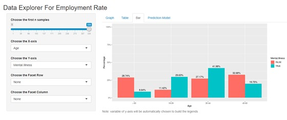

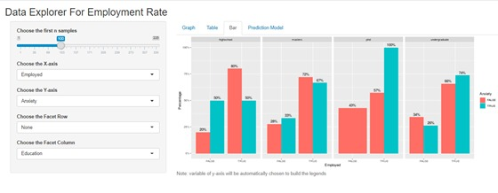

We can see from scatter plots at the graph charts below, with all the samples, people that is employed and suffered mental illness is the more likely to be the completed undergraduate students. It is found that women is likely to get mental health problems such as depression than men.

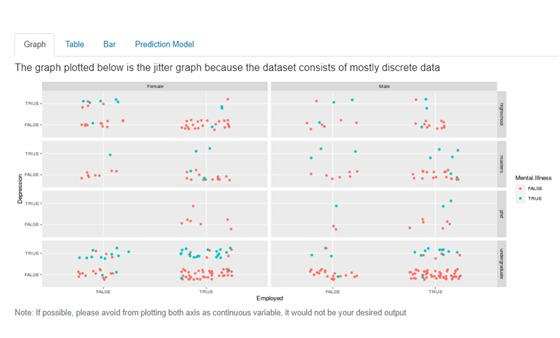

### Conclusion

As we all know, mental health problems has become such a serious issue in 21st century, especially among youngsters and adults. We demonstrate that data science can be applied to find the factors that affect the employment rate . From the analysis and factors that we obtained, we can find the linkage between the employment rate and the mental illness. Although the prediction might be not accurate, we can still fix the problem with other approaches. The model need be trained with more data so that we can make the better accuracy for us to predict the outcome for data scientists to produce data insights, but there is much more to be done now and in the future.